# CUBI advanced R bioinformatics course / 02

2020-05-12

## Distributions

## There are many types of distributions

## Normal distribution

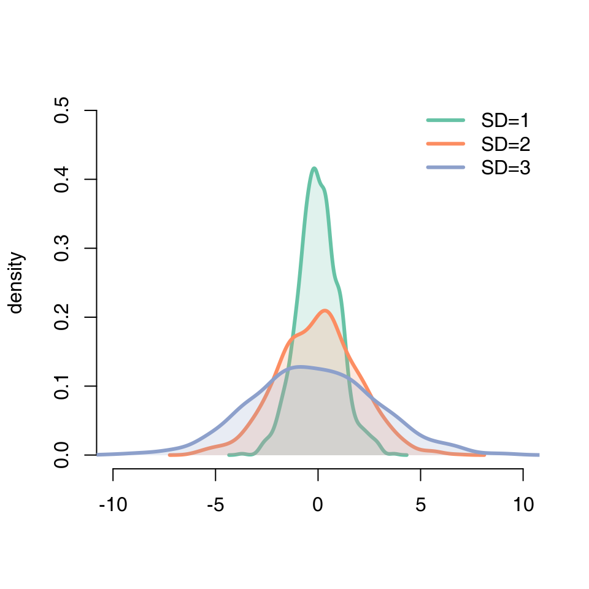

## Binomial distribution

[figure not shown]

## Binomial distribution, 2

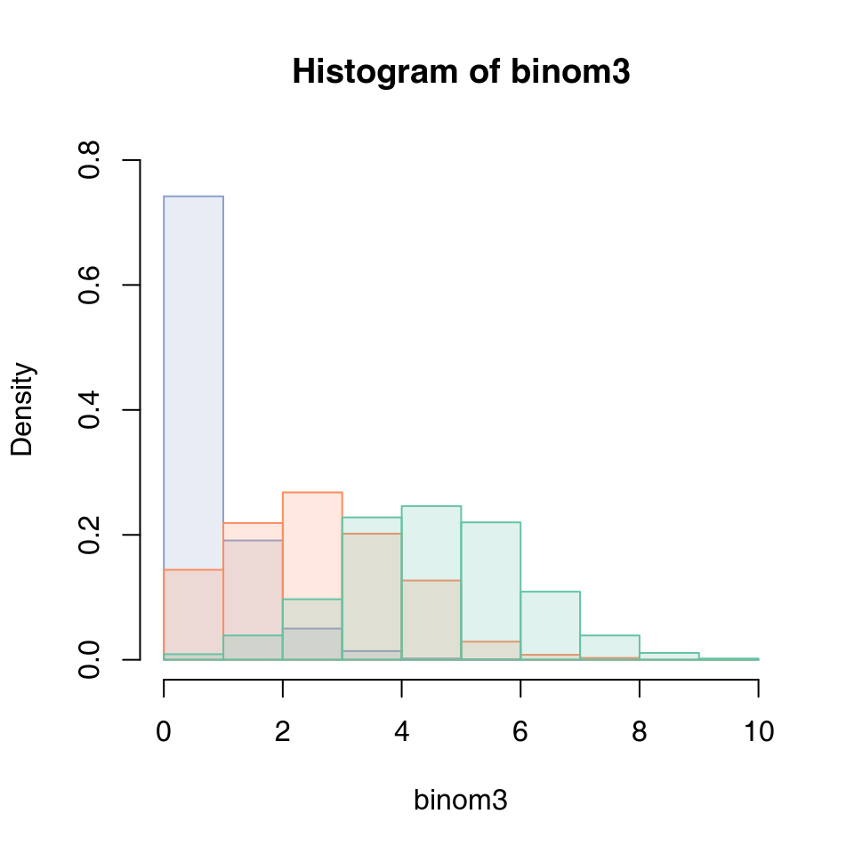

[figure not shown]

## Demonstration

R is a good tool to play with distributions and simulate data.

## Distribution of the count data

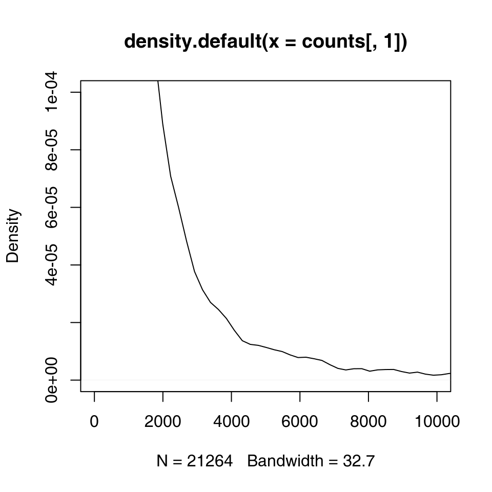

## Distribution of count data

Binomial: we count some items out of a certain total. With binomial distribution, we must know what the *total* is. But what if we only have the count?

## Negative binomial distribution

For a given N, f(N) is the number of times we need to throw a coin to get N successes. So, we have two parameters: N (number of successes) and p (probability of obtaining Head in a coin throw).

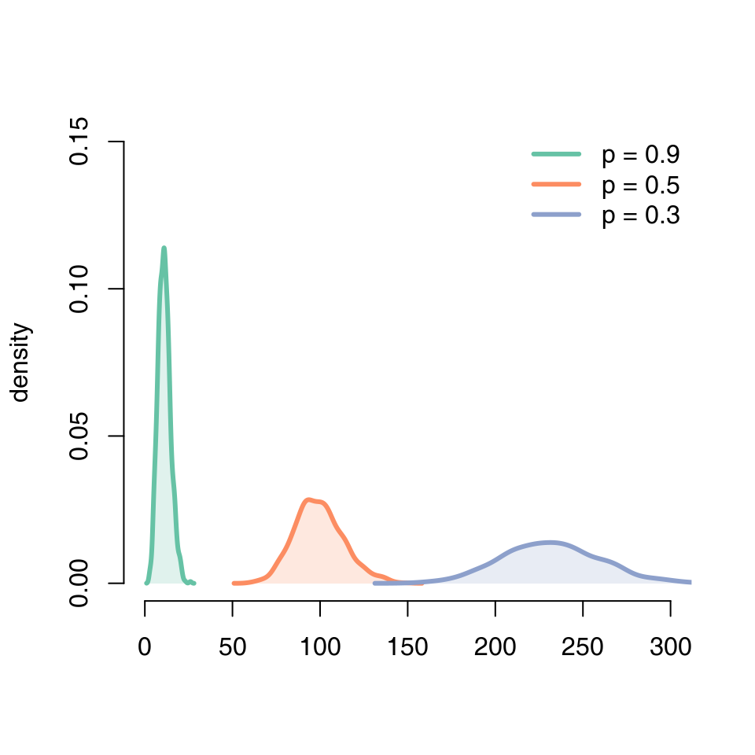

## Negative binomial distribution

Alternatively, we can use a definition where the parameters are \(\mu\) (mean result) and \(\alpha\) (dispersion).

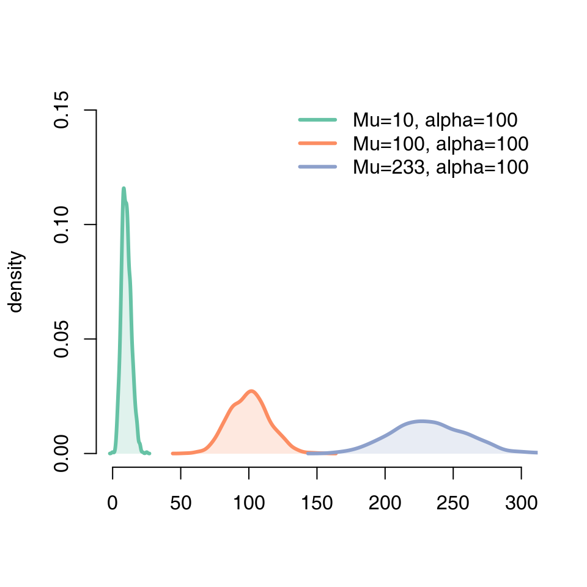

## Negative binomial distribution

What about different dispersions? (\(\alpha\) parameter)

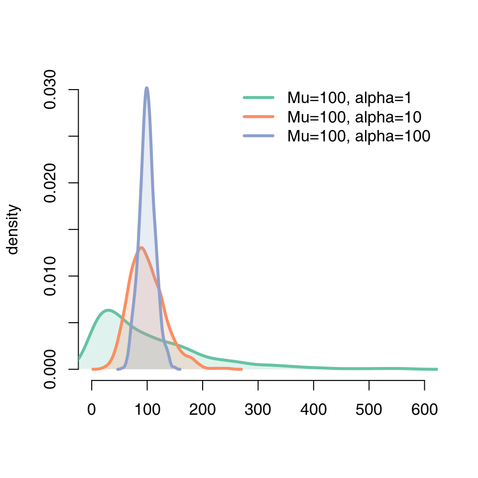